# Analysis: Dataset, Objectives and Structure

Felix & Mai-Britt , University of Potsdam

15.03 January 2023

## EDGAR- FOOD

### Summary of the Dataset

# Our Dataset

Our Dataset is from the EDGAR - Emissions Database for Global Atmospheric Research. This dataset is a global database of anthropogenic greenhouse gas emissions as well as air pollutants on Earth. The dataset is indepent and freely accessible under https://edgar.jrc.ec.europa.eu/ [Edgar, 2023]

For our analysis we focused on the dataset that includes global carbon dioxide emissions of the food system (https://edgar.jrc.ec.europa.eu/edgar_food).[Edgar-Food, 2023]

## Relevance of the Dataset

Globally 1/3 of all GHG emissions are linked to the food system, summing up to a total of 18 Gtonnes (2015). Carbon dioxide accounts for the largest share of this emissions (52%), followed by methane (35%), Nitrous oxide (11%) and fluorinated gases (2%).

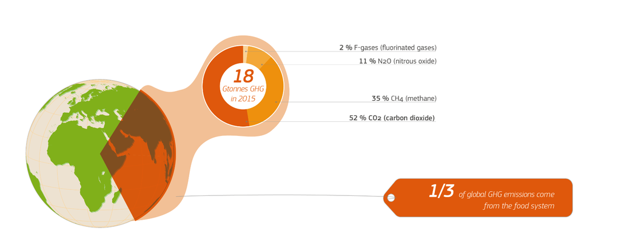

Impact of the food system on the global GHG emissions (Source: Edgar, 2023)

To reduce these emissions it is inevitable to understand their origin. To mitigate the impact of the food system it is important to not only think about the land use change but also about the food production, the processing, the distribution, the consumption and last but not least the waste.

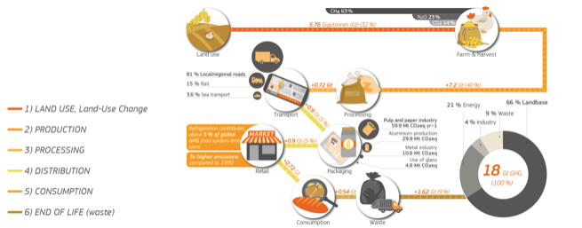

Manufacturing chain of the food (Source: EDGAR, 2023)

## Goals for our statistical Analysis

- To highlight regional differences of the shares that the food system holds within the total GHG emissions of a country
- To analyze the difference in the different steps of the production chain
- To understand emission intensive parts of the food system
- To assess the trend of the GHG emissions linked to the food system